# Project 1

TMA4268 Statistical Learning V2020

Casper Stenersen & Tinius Mellbye

12 February, 2021

# Problem A

## 1

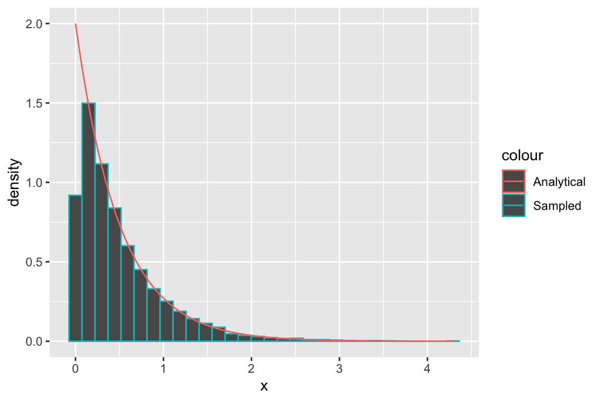

```r
exp_generator = function(n = 1, lambda) {
    u = runif(n = n)  # u = a vector of n uniformly distributed numbers between 0 and 1
    return(-1/lambda * log(u))
}
lambda = 2
n = 10000
exp_vector = data.frame(x = exp_generator(n, lambda))


ggplot(exp_vector, aes(x)) + geom_histogram(aes(y = stat(density), color = "Sampled")) +
    stat_function(fun = dexp, args = lambda, aes(color = "Analytical"))
```

## 2

```r
rg = function(n, alpha) {
    u = runif(n = n)
    boundary = exp(1)/(alpha + exp(1))
    left_boundary = u < boundary
    right_boundary = !left_boundary

    u[left_boundary] = (u[left_boundary]/boundary)^(1/alpha)
    u[right_boundary] = -log((1 - u[right_boundary])/(boundary * alpha))
    return(u)
}

dg = function(x, alpha = 1) {
    c = alpha * exp(1)/(alpha + exp(1))
    d <- rep(0, length(x))
    left_indices <- 0 < x & x < 1
    right_indices <- 1 <= x
    d[left_indices] <- c * (x[left_indices]^(alpha - 1))
    d[right_indices] <- c * exp(-x[right_indices])
    return(d)
}
```

# Problem B

## 1

### a)

We have the gamma distribution constrained to $\alpha \in (0, 1)$ and $\beta = 1$ i.e:
$$\begin{align*}
f(x) =
\begin{cases}
\frac{1}{\Gamma(\alpha)}x^{\alpha - 1}e^{-x}, \quad 0 < x\\
0, \hspace{48pt} \text{otherwise}
\end{cases}
\end{align*}$$

Furthermore, we have that $U \sim \mathrm{unif}(0, 1)$. Thus

$$\begin{align*}
\text{Acceptance probability} &= P\Big{(}U ≤ \frac{f(x)}{Ag(x)}\Big{)} \\
&= \int_{\mathbb{R}} P\big{(}U ≤ \frac{f(x)}{Ag(x)} \big{|} x\big{)} g(x) dx \\
&= \int_{\mathbb{R}}\frac{f(x)}{Ag(x)}g(x)dx \\
&= \frac{1}{A}\int_{0}^{\infty}f(x)dx = \frac{1}{A}
\end{align*}$$

Need to find $A$; $Ag(x) ≥ f(x) \, \forall x \Leftrightarrow A ≥ \frac{f(x)}{g(x)}$. ($A ≥ 1$, but $A = 1 \Rightarrow f(x) = g(x)$ and the procedure is unnecessary) We want A as small as possible. Thus,

$$A = \sup_{x>0}\frac{f(x)}{g(x)}$$
First we investigate the case when $0 < x < 1$

$$\frac{f(x)}{g(x)}= \frac{\frac{1}{\Gamma(\alpha)}x^{\alpha - 1}e^{-x}} {cx^{\alpha-1}}
= \frac{e^{-x}}{\Gamma(\alpha)c}
= \frac{e^{-x}(\alpha^{-1} + e^{-1})}{\Gamma(\alpha)}$$
Supremum provided when $x \rightarrow 0:$

$$\Longrightarrow A = \frac{\alpha^{-1} + e^{-1}}{\Gamma(\alpha)}$$
Now, the case when $x ≥ 1$:
$$\frac{f(x)}{g(x)} = \frac{\frac{1}{\Gamma(\alpha)}x^{\alpha - 1}e^{-x}} {ce^{-x}}
= \frac{x^{\alpha-1}}{\Gamma(\alpha)c}$$

which is maximized for $x = 1$

$$\Longrightarrow A = \frac{\alpha^{-1} + e^{-1}}{\Gamma(\alpha)}$$
same as for $0 < x < 1$. Hence, the
$$\text{Acceptance probability} = \frac{\Gamma(\alpha)}{\alpha^{-1} + e^{-1}}$$

### b)

Now we us the acceptance probability above and rejection sampling to sample from the gamma distribution.

```r
gamma_samples = function(n = 1, alpha = 0.5, beta = 1) {
    # the acceptance probability
    a = (1/alpha + 1/exp(1))/gamma(alpha)
    # initialise vector of samples
    samples = c()
    # number of succesful samples
    num_of_samp = 0
    repeat {
        # Generating n uniform samples on (0, 1)
        u = runif(n)
        # genereate samples from g as in A)
        x = rg(n = n, alpha = alpha)
        # probability of accepting
        prob = dgamma(x, alpha, beta)/(a * dg(x, alpha))
        # appending the x-s where u < prob
        samples = c(samples, x[u < prob])
        # increas num_of_samp by the number of samples accepted
        num_of_samp = num_of_samp + length(x[u < prob])
        # Here we remove every accepted samples in addition to the n we want
        if (length(samples) > n) {
            samples = samples[1:n]
            break
        }
    }
    return(samples)
}
# We genereate many samples each iteration to save number of iterations in the
# loop. We do this because vector operations are faster than loops, in R.
```

#### We compare our implementation wth the theoretical distribution

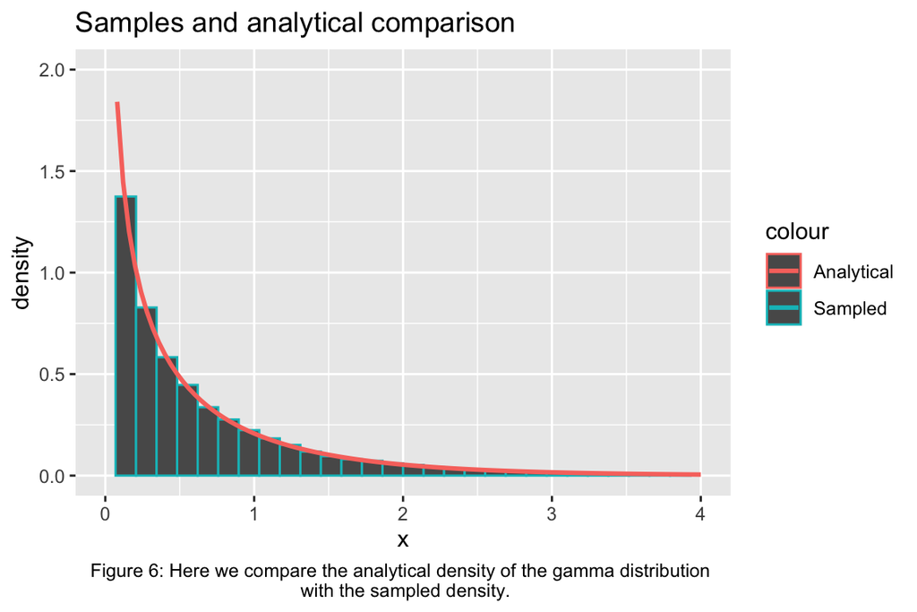

```r
alpha = 0.5
# We draw samples
smpls = gamma_samples(n = 1e+05, alpha = alpha)

# sample mean and variance to use for comparison
mn = mean(smpls)
vr = var(smpls)

# to be able to use ggplot we transform the samples to a data frame
smpls = data.frame(samples = smpls)
# making a nice plot for comparison
ggplot(data = smpls, aes(x = samples)) + geom_histogram(data = smpls, aes(x = samples,
    y = ..density.., color = "Sampled")) + stat_function(fun = dgamma, geom = "line",
    size = 1, args = list(shape = alpha, rate = 1), aes(x = samples, color = "Analytical")) +
    ylim(0, 2) + xlim(0, 4) + ggtitle("Samples and analytical comparison") + labs(x = "x",
    y = "density", caption = "Figure 6: Here we compare the analytical density of the gamma distribution \n with the sampled density.") +
    theme(plot.caption = element_text(hjust = 0.5))
```

We see that our samples match the teoretical distribution very well.

Furthermore, we compare mean and variance

```r
beta = 1
mean_var_matrix = matrix(c(mn, vr, alpha * beta, alpha * beta^2), ncol = 2, byrow = TRUE)
colnames(mean_var_matrix) = c("Mean", "Variance")
rownames(mean_var_matrix) = c("Sample", "Theoretical")
mean_var_matrix
```

```
##                  Mean  Variance
## Sample      0.4998177 0.4976386
## Theoretical 0.5000000 0.5000000
```

We can see that the sample mean and variance are fairly similar to that of the theoretical.

## 2

Now we investigate the case when $\alpha > 1$ and $\beta = 1$ through ratio of uniform methods. We have

$$C_f = \bigg \{(x_1, x_2): 0 \leq x_1 \leq \sqrt{f^*\big{(}\frac{x_2}{x_1}\big{)}} \bigg \}, \quad f^*(x) = \begin{cases}
x^{\alpha-1}e^{-x}, \quad 0 < x, \\
0, \quad \text{otherwise}.
\end{cases}$$

Then $y = \frac{x_2}{x_1}$ will be Gamma($\alpha, 1$) distributed.

We start by finding expressions for $a, b_+$ and $b_-$.

### a)

$$a = \sqrt{\sup_{x} f^{\star}(x)}$$
For $x≤0, \; f^{\star}(x) = 0$ thus we examine the case when $x>0$:
$$\sup_{x>0}f^{\star}(x) = \sup_{x>0}x^{\alpha-1}e^{-x}$$
Hence,
$$\begin{align*}
\frac{d}{dx}f^{\star}(x) &= (\alpha - 1)x^{\alpha-2}e^{-x} - x^{\alpha-1}e^{-x} \\
&= x^{\alpha-2}e^{-x}((\alpha - 1) - x) = 0 \\
\Longrightarrow x &= \alpha - 1
\end{align*}$$

moreover

$$\begin{align*}
\begin{Bmatrix}
f^{\star}(x) \overset{x \rightarrow 0}{\longrightarrow} 0 \\
f^{\star}(x) \overset{x \rightarrow \infty}{\longrightarrow} 0 \\
f^{\star}(\alpha-1) ≥ 0
\end{Bmatrix}
\overset{f^{\star}(x) \, \text{cont.}}{\Longrightarrow} x = \alpha-1 \; \text{provides a maximum.}
\end{align*}$$

As a result,
$$a = (\alpha -1)^{(\alpha -1)/2}e^{-(\alpha)+1)/2}$$

Now we find
$$b_+ = \sqrt{\sup_{x≥0}(x^2f^{\star}(x))}$$
and
$$\sup_{x≥0}(x^2f^{\star}(x)) = \sup_{x≥0}x^{\alpha+1}e^{-x} > 0 \; \forall x≥0$$
We will now find the derivative and set it to 0.
$$\begin{align*}
\frac{d}{dx} x^{(\alpha + 1)}e^{-x}
&= (\alpha+1)x^{\alpha}e^{-x} - x^{\alpha+1}e^{-x} \\
&= x^{\alpha}e^{-x}((\alpha + 1) - x) = 0 \\
\Longrightarrow x &= \alpha + 1
\end{align*}$$

Additionally

$$\begin{align*}
\begin{Bmatrix}
x^2f^{\star}(x) \overset{x \rightarrow 0}{\longrightarrow} 0 \\
x^2f^{\star}(x) \overset{x \rightarrow \infty}{\longrightarrow} 0
\end{Bmatrix}
\overset{x^2f^{\star}(x) \, \text{cont.}}{\Longrightarrow} b_+ = (\alpha+1)^{(\alpha+1)/2}e^{-(\alpha+1)/2}
\end{align*}$$

Furthermore, because
$$f^{\star}(x) \overset{x≤0}{=} 0$$
we get that
$$\quad b_- = -\sqrt{\sup_{x≤0}(x^2f^{\star}(x))} = 0$$

### b)

Our implementation of the ratio of uniform method for the Gamma distribution. Implemented on a log-scale to not get NAs, and we get:

$$\begin{align*}
\log(a) &= \frac{\alpha-1}{2}(\log(\alpha - 1) - 1) \\
\log(b_+) &= \frac{\alpha + 1}{2}(\log(\alpha + 1) - 1)
\end{align*}$$

Note that in the code below, we check if $(x_1, x_2) \in C_f$, $\Rightarrow 0 ≤ x_1 ≤ \sqrt{f^{\star}(x_2/x_1)}$, on a log-scale. Hence,

$$\begin{align*}
\log(x_1) &≤ \log \sqrt{f^{\star}(\frac{x_2}{x_1})} = \frac{1}{2}\log(\frac{x_2}{x_1})^{\alpha - 1} + \frac{1}{2}\log e^{-x_2/x_1} \\
&= \frac{1}{2}\log(\frac{x_2}{x_1})^{\alpha - 1} - \frac{1}{2}\frac{x_2}{x_1} \\
&= \frac{\alpha - 1}{2}\log(\frac{x_2}{x_1}) - \frac{1}{2}\exp (\log (x_2/x_1)) \\
&= \frac{\alpha - 1}{2}(\log(x_2) - \log(x_1)) - \frac{1}{2}\exp (\log(x_2) - \log(x_1)) \\
\Longrightarrow \log x_1(\alpha + 1) &≤ (\alpha - 1)\log x_2 - \exp(\log x_2 - \log x_1)
\end{align*}$$

Furthermore,

$$\log x_1 = \log a + \log u_1, \quad u_1 \sim U(0, 1)$$

$$\log x_2 = \log b_+ + \log u_2, \quad u_2 \sim U(0, 1)$$

```r
rum_gamma = function(n = 1, alpha = 2, beta = 1) {
    # Calculating the limits of the sample region using the log-transformation of a
    # and b+ (we do not need b_)
    log_a = 1/2 * (alpha - 1) * (log(alpha - 1) - 1)
    # log of b_{+}
    log_b2 = 1/2 * (alpha + 1) * (log(alpha + 1) - 1)

    # creat an empty vector to store samples
    samples = c()
    tries = 0
    while (length(samples) < n) {
        tries = tries + 1
        # Sampling from the uniform distribution on (0, 1) and transforming the samples
        # to appropriate regions
        log_x1 = log_a + log(runif(1))
        log_x2 = log_b2 + log(runif(1))
        if ((alpha + 1) * log_x1 <= (alpha - 1) * log_x2 - exp(log_x2 - log_x1)) {
            y = exp(log_x2 - log_x1)
            samples = c(samples, y)
        }
    }
    return(list(tries = tries, samples = samples))
}
```

#### Compare our implementation with the teoretical distribution

We plot one realisation to illustrate that the algorithm works

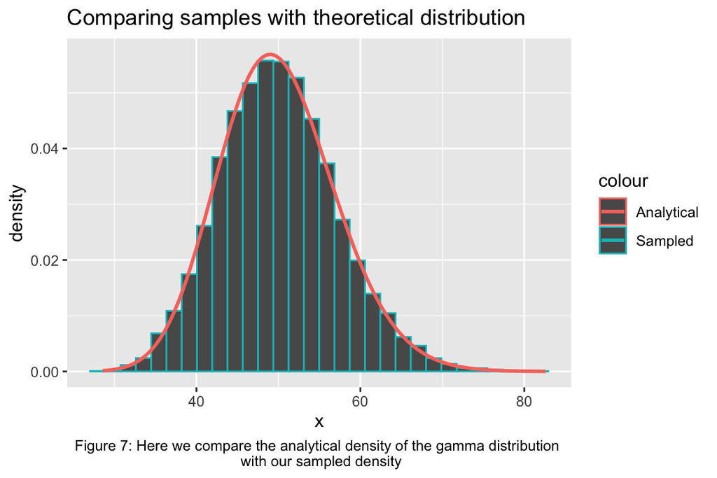

```r
alpha = 50
n = 20000
# Sample from the algorithm
smpls_rum = rum_gamma(n = n, alpha = alpha)
tries = smpls_rum$tries
samples_rum = smpls_rum$samples
# sample mean and variance
mn_rum = mean(samples_rum)
vr_rum = var(samples_rum)

# to be able to use ggplot we transform the samples to a data frame
smpls_rum = data.frame(samples = samples_rum)

# making a nice plot for comparison
ggplot(data = smpls_rum, aes(x = samples)) + geom_histogram(data = smpls_rum, aes(x = samples,
    y = ..density.., color = "Sampled")) + stat_function(fun = dgamma, geom = "line",
    size = 1, args = list(shape = alpha, rate = 1), aes(x = samples, color = "Analytical")) +
    ggtitle("Comparing samples with theoretical distribution") + labs(x = "x", y = "density",
    caption = "Figure 7: Here we compare the analytical density of the gamma distribution \n with our sampled density") +
    theme(plot.caption = element_text(hjust = 0.5))
```

Figure 7 shows that our implementation resambles the analytical distribution quite well.

Furthermore, we compare the means and variances

```r
beta = 1
mean_var_matrix = matrix(c(mn_rum, vr_rum, alpha * beta, alpha * beta^2), ncol = 2,
    byrow = TRUE)
colnames(mean_var_matrix) = c("Mean", "Var")
rownames(mean_var_matrix) = c("Sample", "Theoretical")
mean_var_matrix
```

```
##                 Mean      Var
## Sample      50.02898 50.57268
## Theoretical 50.00000 50.00000
```

We can see that the sample mean and variance are fairly similar to that of the theoretical.

### Here we plot how many tries are needed for different alphas

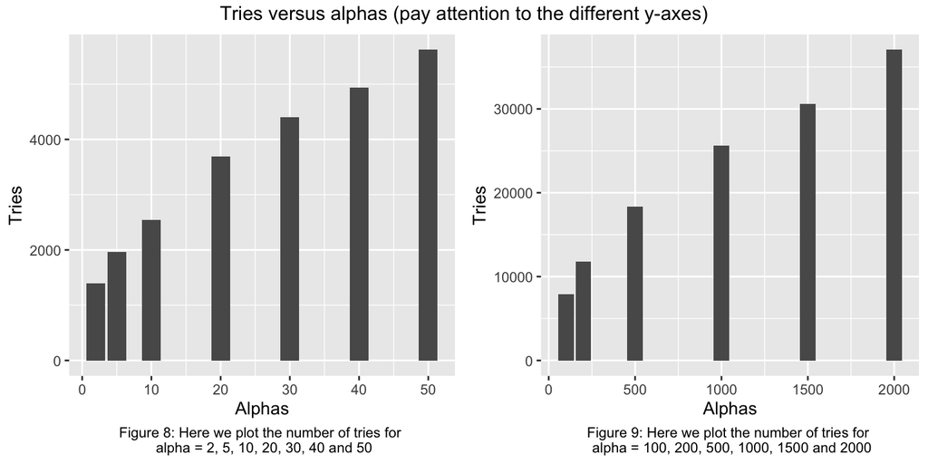

```r
tries_count = function(alphas) {
    result = c()
    n = 1000
    for (i in 1:length(alphas)) {
        # Sample from the algorithm
        tries = smpls_rum = rum_gamma(n = n, alpha = alphas[i])$tries
        vect = c(alphas[i], tries)
        result = cbind(result, vect)
    }
    result = data.frame(rates = t(result))
    colnames(result) = c("Alphas", "Tries")
    return(result)
}

small_alphas = c(2, 5, 10, 20, 30, 40, 50)
df_small_alphas = tries_count(small_alphas)
large_alphas = c(100, 200, 500, 1000, 1500, 2000)
df_large_alphas = tries_count(large_alphas)


small = ggplot(data = df_small_alphas) + geom_col(data = df_small_alphas, aes(x = Alphas,
    y = Tries)) + labs(x = "Alphas", y = "Tries", caption = "Figure 8: Here we plot the number of tries for \n alpha = 2, 5, 10, 20, 30, 40 and 50") +
    theme(plot.caption = element_text(hjust = 0.5))

large = ggplot(data = df_large_alphas) + geom_col(data = df_large_alphas, aes(x = Alphas,
    y = Tries)) + labs(x = "Alphas", y = "Tries", caption = "Figure 9: Here we plot the number of tries for \n alpha = 100, 200, 500, 1000, 1500 and 2000") +
    theme(plot.caption = element_text(hjust = 0.5))

# To get the plots next to each other
grid.arrange(small, large, ncol = 2, top = "Tries versus alphas (pay attention to the different y-axes)")
```

#### Interpretation

We see from figure 8 and 9 that as $\alpha$ increases the number of tries needed to sample $n = 1000$ samples increases i.e. the algorithm becomes less efficient as $\alpha$ increase.

## 3

We seek an implementation of the gamma distribution for any $\alpha > 0$ and $\beta > 0$.

We will use that for $X \sim \text{Gamma}(\alpha, 1)$ and $c \in \mathbb{R}_+$ we get from the moment generating function that
$$M_{Xc}(t) = E(e^{Xct}) = M_X(ct) = \bigg{(}\frac{1}{1-ct}\bigg{)}^\alpha \\
\Longrightarrow Xc \sim \text{Gamma}(\alpha, c)$$
Thus we can make a simple function using `gamma_samples` and `rum_gamma` from above. These two covers the cases when $\alpha < 1$ and $\alpha > 1$. When $\alpha = 1$ we use the fact that when $X \sim \text{Gamma}(1, \beta)$ we have that $X \sim \text{Exp}(\frac{1}{\beta})$ and use the function `exp_generator` from A1.

*We have the inversion of the $\beta$ parameter in the exponential distribution due to how we implemented the function. If we were using a different parametrisation, we would have that* $X \sim \text{Exp}(\beta)$

```r
gam4 = function(n = 1, alpha = 2, beta = 1) {
    if (alpha > 1) {
        return(beta * rum_gamma(n, alpha)$samples)
    } else if (0 < alpha && alpha < 1) {
        return(beta * gamma_samples(n, alpha))
    } else if (alpha == 1) {
        return(exp_generator(n, 1/beta))
    }
}
```

#### Comparing

Because we above have illustrated that the functions we use work, as well as considering the proof, we do not include plots for the three cases $0 < \alpha < 1$, $\alpha = 1$ and $\alpha > 1$ as it demands a fair amount of space. Though, we do include a comparison of the mean and variance for the three cases.

```r
mean_var_comparison = function(alpha, beta, n = 1e+05) {
    # Draw samples
    gam4_realizations = gam4(n, alpha, beta)
    # mean and variance from gam4 samples
    mn_gam4 = mean(gam4_realizations)
    vr_gam4 = var(gam4_realizations)
    # Create a matrix Theoretical mean = alpha*beta Theoretical variance =
    # alpha*beta^2
    mean_var_matrix = matrix(c(mn_gam4, vr_gam4, alpha * beta, alpha * beta^2), ncol = 2,
        byrow = TRUE)
    # We set colnames and rownames to make easier to interpret
    colnames(mean_var_matrix) = c("Mean", "Variance")
    rownames(mean_var_matrix) = c("Sample", "Theoretical")

    mean_var_matrix
}
```

We set $\beta = 10$ in all the cases, $\alpha$ is tested for the three cases.

$0 < \alpha < 1$:

```r
mean_var_comparison(0.5, 10)
```

```
##                 Mean Variance
## Sample      5.034862 51.42243
## Theoretical 5.000000 50.00000
```

$\alpha = 1$:

```r
mean_var_comparison(1, 10)
```

```
##                  Mean Variance
## Sample       9.951245  98.7271
## Theoretical 10.000000 100.0000
```

$1 < \alpha$:

```r
mean_var_comparison(50, 10)
```

```
##                 Mean Variance
## Sample      500.5739 5024.029
## Theoretical 500.0000 5000.000
```

## 4

### a)

When
$$X \sim \text{Gamma}(\alpha, 1) \\
Y \sim \text{Gamma}(\beta, 1)$$
are independent, and from above we have learned that
$$X+Y = V \sim \text{Gamma}(\alpha + \beta, 1).$$
The joint pdf of $X$ and $Y$ is
$$f_{X, Y}(x, y) = \frac{1}{\Gamma(\alpha)\Gamma(\beta)}x^{\alpha-1}y^{\beta-1}e^{-(x+y)}, \quad x,y ≥ 0$$
We further define
$$U = \frac{X}{X + Y} = \frac{X}{V}$$
Then
$$X = UV ≥0 \quad \text{and} \quad Y = V-X = V-UV = V(1-U) ≥0$$
Hence we have two cases

1. $V ≥ 0 \Rightarrow 0 ≤ U ≤ 1$
2. $V < 0 \Rightarrow U ≤ 0$ and $U ≥ 1$ (Which clearly is not possible)

$$\Longrightarrow U \in [0, 1]$$

Now we find the determinant of the Jacobian of the transformation

$$|J| = \Bigg|\frac{\partial(X,Y)}{\partial(U, V)}\Bigg|
= \begin{vmatrix}
V & U \\
-V & 1-V
\end{vmatrix} = V - UV + UV = V$$
Hence, we get

$$\begin{align*}
f_{U, V}(u, v) &= \frac{1}{\Gamma(\alpha)\Gamma(\beta)}(uv)^{\alpha-1}v(1-u))^{\beta-1}e^{-v} \Bigg|\frac{\partial(x, y)}{\partial(u, v)}\Bigg| \\
&= \frac{1}{\Gamma(\alpha)\Gamma(\beta)}v^{\alpha-1+\beta-1+1} u^{\alpha-1}(1-u)^{\beta-1}e^{-v} \\
&= \frac{1}{\Gamma(\alpha)\Gamma(\beta)}v^{\alpha+\beta-1}e^{-v} u^{\alpha-1}(1-u)^{\beta-1} \frac{\Gamma(\alpha + \beta)}{\Gamma(\alpha + \beta)} \\
&= \underline{\frac{1}{\Gamma(\alpha + \beta)}v^{(\alpha + \beta) - 1}e^{-v}} \;
\underline{\frac{\Gamma(\alpha + \beta)}{\Gamma(\alpha)\Gamma(\beta)} u^{\alpha-1}(1-u)^{\beta-1}}
\end{align*}$$

We define the first part of the expression as $f_V(v)$ which we identify to be tha Gamma density with variables $\alpha + \beta$ and $1$, as stated above. Furthermore, the last part we define as $f_U(u)$ and see that it is the pdf of a Beta distributed variable with parameters $\alpha$ and $\beta$. Since these pdfs are entirely seperated we can conclude that
$$U \sim \text{Beta}(\alpha, \beta)$$
with $u \in [0, 1]$ from above.
$$\qquad \qquad \qquad \qquad \qquad \qquad \qquad \qquad \qquad\qquad \qquad \qquad \qquad \qquad \qquad \qquad \blacksquare$$

### b)

By using what we just proved and the function `gam4`, we can simulate from a Beta distribution.

```r
beta_gen = function(n, alpha, beta) {
    x = gam4(n, alpha)
    y = gam4(n, beta)
    return(x/(x + y))
}
```

#### Plotting

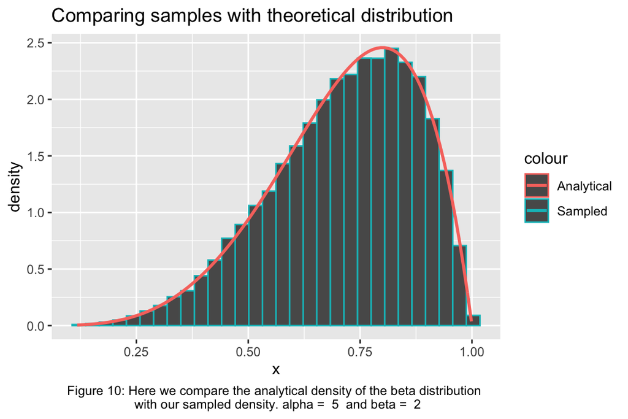

```r
n = 20000
alpha = 5
beta = 2
beta_vect = beta_gen(n, alpha, beta)
# Sample mean and variance
mn_beta = mean(beta_vect)
vr_beta = var(beta_vect)

beta_vect = data.frame(samples = beta_vect)
# Plot
ggplot(data = beta_vect, aes(x = samples)) + geom_histogram(data = beta_vect, aes(x = samples,
    y = ..density.., color = "Sampled")) + stat_function(fun = dbeta, geom = "line",
    size = 1, args = list(shape1 = alpha, shape2 = beta), aes(x = samples, color = "Analytical")) +
    ggtitle("Comparing samples with theoretical distribution") + labs(x = "x", y = "density",
    caption = paste("Figure 10: Here we compare the analytical density of the beta distribution \n with our sampled density. alpha = ",
        alpha, " and beta = ", beta)) + theme(plot.caption = element_text(hjust = 0.5))
```

Figure 10 illustrates that our samples are very close to the analytical pdf.

#### Comparing mean and variance

```r
mean_var_matrix = matrix(c(mn_beta, vr_beta, alpha/(alpha + beta), alpha * beta/((alpha +
    beta)^2 * (alpha + beta + 1))), ncol = 2, byrow = TRUE)
colnames(mean_var_matrix) = c("Mean", "Var")
rownames(mean_var_matrix) = c("Sample", "Theoretical")
mean_var_matrix
```

```
##                  Mean        Var
## Sample      0.7132631 0.02584487
## Theoretical 0.7142857 0.02551020
```

We can see that the sample mean and variance are fairly similar to that of the theoretical.